# Investments

Week 3 – Lecture  
Utz Weitzel – VU Finance

**Note**

To run the R code in this file, first, open a new R script in RStudio (top dropdown menu: file/new file/R script). Then copy, one by one, the r code chunks in this file into that R script in RStudio. Use the little clipboard symbol at the right hand side of each code chunk to copy the code. Then, in RStudio, execute all the commands line by line with the ‘run’ command in the upper right corner of the source window. (Put your cursor on the line you want to execute before you click run.)

# Prepare session

## Tidyverse

In RStudio, open a project, or make a new one.

If you haven’t done so already, install the tidyverse package

```r
if(!require(tidyverse)) install.packages("tidyverse")
```

Then load the package. This is needed at the start of every new session.

```r
library(tidyverse)
options(dplyr.summarise.inform = FALSE)
```

**Note**

The options() command above suppresses some messages when grouping and summarizing, which are helpful for debugging but can also be distracting or clutter output. Setting this option to FALSE leads to a cleaner console output.

.

## Import data

For this section, we import dataset `df301` with *monthly* data for Vanguard Exchange Traded Funds, listed in `ticker` ([details on tickers](https://investor.vanguard.com/investment-products/list/etfs)) by `date`, `year`, and `month` .

Main variables are: `re` = total ETF portfolio returns; `SP500` = total market index returns; `rf` = risk-free returns to 4-week T-bills.

```r
df301 = read_csv("df301.csv", show_col_types=FALSE)

View(df301)
```

**Important**

Don’t forget to copy the file from Canvas to your project folder first.

.

## Excess returns

For all portfolio measures we use *excess* returns

```r
df301x = df301 |>
  mutate(rx = re-rf) |>    # excess portfolio return
  mutate(rm = SP500-rf) |> # excess market return
  select(-re, -rf, -SP500) # cleaning up

View(df301x)
```

.

# Portfolio measures

## Portfolio rx & sd

```r
dfport = df301x |>
  group_by(ticker) |>
  summarize(
    rx_av = mean(rx),
    rm_av = mean(rm),
    rx_sd = sd(rx),
    rm_sd = sd(rm))

View(dfport)
```

.

### Sharpe

To include some sort of risk-adjustment into portfolio performance, Sharpe is the go-to ratio.

```r
dfport = dfport |>
  mutate(psharpe = rx_av/rx_sd) |> # Portfolio Sharpe ratio

  # Sharpe ratio of market
  mutate(msharpe = rm_av/rm_sd) |>

  # Performance difference
  mutate(diffshp = psharpe - msharpe)

View(dfport)
```

.

### M-squared

M^2 basically transforms the Sharpe ratio into economically meaningful return percentages (vis-a-vis another benchmark portfolio, mostly the market portfolio).

```r
dfport = dfport |>
  mutate(rx_pstar = rm_sd/rx_sd * rx_av) |>  # rx adj. portf, assuming rf = 0
  mutate(pM2      = rx_pstar - rm_av)        # M2 (performance delta)

  # M2 of market: 0

View(dfport)
```

.

## Portfolio regression

For the other portfolio performance measures, we need to estimate an asset pricing model (here, CAPM to keep it simple) and then use the regression results. Lets first focus on just one portfolio, `VGT`, which is the Vanguard ETF for the sector “information technology” ([see details](https://investor.vanguard.com/investment-products/etfs/profile/vgt)).

```r
lm_VGT = lm(rx ~ rm, data=df301x, subset = (ticker=="VGT")) # just VGT

summary(lm_VGT)
```

Then we save the estimates for alpha, beta, and the standard deviation of the residuals.

```r
dfport_VGT = dfport |>
  filter(ticker == "VGT") |>
  mutate(alpha = coef(lm_VGT)["(Intercept)"]) |> # or: coef(lm_VGT)[1]
  mutate(beta  = coef(lm_VGT)["rm"]) |>
  mutate(sd_e  = sd(residuals(lm_VGT)))          # or: sd(resid(lm_VGT))

View(dfport_VGT)
```

**Note**

Of course, you can also save the estimates without the tidyverse as values (`v_`):

```r
v_alpha = coef(lm_VGT)["(Intercept)"]
v_beta  = coef(lm_VGT)["rm"]
v_sd_e  = sd(residuals(lm_VGT))

cat("alpha:", v_alpha, "\nbeta:", v_beta, "\nSD of residuals:", v_sd_e)
```

```
alpha: 0.007305466
beta: 1.156517
SD of residuals: 0.02409152
```

.

### Jensen’s alpha

For Jensen’s alpha, usually the CAPM is estimated, but any other asset pricing model also works (for example, FF3-factor alpha). As we estimated the CAPM above, Jensen’s alpha refers to that model

```r
dfport_VGT = dfport_VGT |>
  mutate(Jensen = rx_av - beta * rm_av)
  # Jensen (alpha) of market: 0

View(dfport_VGT)
```

**Note**

Again, this can also be done without the tidyverse, by referring to the values in dataframe `dfport_VGT` more directly:

```r
v_Jensen = dfport_VGT$rx_av - dfport_VGT$beta * dfport_VGT$rm_av

# alternatively, if you ran the code chunk in the note after the regression:
# v_Jensen = dfport_VGT$rx_av - v_beta * dfport_VGT$rm_av

cat("Jensen's alpha:", v_Jensen, "\nIntercept (alpha):", dfport_VGT$alpha, "\nJensen's alpha of market: 0")
```

```
Jensen's alpha: 0.007305466
Intercept (alpha): 0.007305466
Jensen's alpha of market: 0
```

As you can see, Jensen’s alpha is identical to the intercept of the regression model `lm_VGT`. So, alternatively, you can also extract Jensen’s alpha as the intercept from the CAPM estimates in `lm_VGT`:

```r
intercept = coef(lm_VGT)["(Intercept)"] # or: coef(lm_VGT)[1]

cat("Intercept:", intercept, "\nJensen's alpha:", v_Jensen, "\nJensen's alpha of market: 0")
```

```
Intercept: 0.007305466
Jensen's alpha: 0.007305466
Jensen's alpha of market: 0
```

.

### Treynor

```r
dfport_VGT = dfport_VGT |>
  mutate(Treynor = rx_av/beta)
  # Treynor of the market: rm_av/1 = rm_av

View(dfport_VGT)
```

**Note**

Directly without the tidyverse:

```r
v_Treynor = dfport_VGT$rx_av/dfport_VGT$beta

# or, if you ran the code chunk in the note after the regression:
# v_Treynor = dfport_VGT$rx_av/v_beta

cat("Treynor portfolio:", v_Treynor, "\nTreynor market:", dfport_VGT$rm_av)
```

```
Treynor portfolio: 0.01426805
Treynor market: 0.007951264
```

.

### Information ratio

```r
dfport_VGT = dfport_VGT |>
  mutate(IR = alpha/sd_e)
  # IR of market: 0 (because market alpha = 0)

View(dfport_VGT)
```

**Note**

Without the tidyverse:

```r
v_IR = dfport_VGT$alpha/dfport_VGT$sd_e

# or, if you ran the code chunk in the note after the regression:
# v_IR = v_alpha/v_sd_e

cat("IR:", v_IR, "\nIR market: 0")
```

```
IR: 0.3032381
IR market: 0
```

.

## Ranking Performance

Most of the performance measures are not so meaningful in isolation. So, we need to compare most of them to the market portfolio (as we did above). Alternatively, we can also compute the measures of several non-market portfolios, in order to compare their relative performance.

Let’s compute all measures for each portfolio and the market index (similar to Table 24.2 in the textbook)

```r
dfport_all = df301x |>
  group_by(ticker) |>

  # per ticker, prepare all values needed for the portfolio measures:
  summarize(
    rx_av = mean(rx),
    rm_av = mean(rm),
    rx_sd = sd(rx),
    rm_sd = sd(rm),
    model = list(lm(rx ~ rm, data = pick(rx, rm)))) |>
  mutate(alpha = map_dbl(model, ~ coef(.)[1])) |>
  mutate(beta  = map_dbl(model, ~ coef(.)["rm"])) |>
  mutate(sd_e  = map_dbl(model, ~ sd(resid(.)))) |>

  # per ticker, compute portfolio measures:
  mutate(psharpe  = rx_av/rx_sd) |>          # Sharpe ratio
  mutate(rx_pstar = rm_sd/rx_sd * rx_av) |>  # rx adj. portf, assuming rf = 0
  mutate(pM2      = rx_pstar - rm_av) |>     # M2 (performance delta)
  mutate(Jensen   = rx_av - beta * rm_av) |> # Jensen's alpha
  mutate(Treynor  = rx_av/beta) |>           # Treynor ratio
  mutate(IR       = alpha/sd_e)              # Information ratio

View(dfport_all)
```

So, which are the highest performances?

```r
max_sharpe  = max(dfport_all$psharpe)
max_M2      = max(dfport_all$pM2)
max_Jensen  = max(dfport_all$Jensen)
max_Treynor = max(dfport_all$Treynor)
max_IR      = max(dfport_all$IR)
```

Let’s also show the ticker names of the corresponding funds:

```r
max_summary   = tibble(
  Measure     = c("Sharpe", "M2", "Jensen", "Treynor", "IR"),
  "Max Value" = c(max_sharpe, max_M2, max_Jensen, max_Treynor, max_IR),
  Ticker      = c(
    dfport_all |> filter(psharpe  == max_sharpe) |> pull(ticker),
    dfport_all |> filter(pM2      == max_M2)     |> pull(ticker),
    dfport_all |> filter(Jensen   == max_Jensen) |> pull(ticker),
    dfport_all |> filter(Treynor  == max_Treynor)|> pull(ticker),
    dfport_all |> filter(IR       == max_IR)     |> pull(ticker)
  )
)
print(max_summary)
```

```
# A tibble: 5 × 3
  Measure `Max Value` Ticker
  <chr>         <dbl> <chr>
1 Sharpe      0.254   VGT
2 M2          0.00530 VGT
3 Jensen      0.00731 VGT
4 Treynor     0.0143  VGT
5 IR          0.611   VV
```

.

# Testing beta

## Import data

For this section, we import dataset `df302` with *monthly* data from 2018 to 2023 for all stocks (listed in `ticker` by `date`, `year`, and `month`) that are included in the S&P500 Index (as of March 2024, based on [this list](https://stockanalysis.com/list/sp-500-stocks/)) with *non-missing return data* for the last six years.

Main variables are: `re` = total ETF portfolio returns; `SP500` = total market index returns; `rf` = risk-free returns to 4-week T-bills; `SML` = excess returns on Fama-French (FF) SMB portfolios; `HML` = excess returns on FF HML portfolios.

```r
df302 = read_csv("df302.csv", show_col_types=FALSE)

View(df302)
```

.

## Excess returns

For most analyses we use *excess* returns, but for the long-short computations of portfolio wealth, *total* returns are also used. We therefore keep `re` and `rf` after computing `rx` and `rm`.

```r
df302 = df302 |>
  mutate(rx = re-rf) |> # excess stock return
  mutate(rm = SP500-rf) # excess market return

# View(df302)
```

.

## 1st-pass regressions

Let’s get each stock’s estimates of a CAPM model (as we did above for the Vanguard ETFs), and some other information (sd, average return, etc.), which we need later on.

```r
df302q = df302 |>
  group_by(ticker) |>
  summarize(model = list(lm(rx ~ rm, data = pick(rx, rm))),
            SP500_hpr = prod(1+SP500, na.rm=T)-1, # used in portfolio wealth
            re_hpr = prod(1+re, na.rm=T)-1,       # used in portfolio wealth
            rf_hpr = prod(1+rf, na.rm=T)-1,       # used in portfolio wealth
            rm_av = mean(rm, na.rm=T),
            rx_av = mean(rx, na.rm=T),
            rx_sd = sd(rx, na.rm=T)) |>
  mutate(alpha = map_dbl(model, ~ coef(.)[1])) |>
  mutate(beta  = map_dbl(model, ~ coef(.)["rm"])) |>
  mutate(sd_e  = map_dbl(model, ~ sd(resid(.)))) |>
  select(-model)

# View(df302q)
```

**Note**

We use the term “first-pass regression” to refer to the fact that the regression results (e.g., a stock’s beta) are used for further analysis in second-pass regressions (as explained in Chapter 13.1).

.

## 2nd-pass regressions

In the second-pass regression, we fit a linear model of each stock’s `beta` and `sd_e` on the average excess stock return `rx_av` (see Chapter 13.1). According to CAPM, we expect to see

- H1: an intercept that is statistically equal to zero
- H2: a coefficient of the stocks’ `beta` is statistically equal to the excess market return `rm_av`
- H3: a coefficient of the stocks’ `sd_e` that is statistically equal to zero

```r
lm_btest = lm(rx_av ~ beta + sd_e, data = df302q)

summary(lm_btest)
```

```
Call:
lm(formula = rx_av ~ beta + sd_e, data = df302q)

Residuals:
      Min        1Q    Median        3Q       Max
-0.027173 -0.004756 -0.000574  0.004172  0.053416

Coefficients:
             Estimate Std. Error t value Pr(>|t|)
(Intercept) 2.198e-05  1.183e-03   0.019    0.985
beta        4.462e-03  1.134e-03   3.935 9.65e-05 ***
sd_e        9.249e-02  1.779e-02   5.199 3.05e-07 ***
---
Signif. codes:  0 '***' 0.001 '**' 0.01 '*' 0.05 '.' 0.1 ' ' 1

Residual standard error: 0.008097 on 450 degrees of freedom
Multiple R-squared:  0.1827,    Adjusted R-squared:  0.1791
F-statistic:  50.3 on 2 and 450 DF,  p-value: < 2.2e-16
```

We do not reject H1, but H3 is clearly rejected with a positive coefficient estimate and a t-value>5. Rejecting H3 means that, in this sample, idiosyncratic risk matters and is priced with higher expected returns (against the prediction of the CAPM).

.

## Test for H2

H2 predicts that the estimated coefficient of `beta` is statistically equal to the average excess market return `rm_av`. Lets compute the confidence interval for the coefficient of beta and see whether it includes `rm_av`.

```r
rm_av_value = unique(df302q$rm_av)
cat("Expected excess return of market: ", rm_av_value, "\n")
```

```
Expected excess return of market:  0.007951264
```

```r
coef_beta = coef(lm_btest)["beta"]
cat("Estimated coefficient of beta:    ", coef_beta, "\n\n")
```

```
Estimated coefficient of beta:     0.004462049
```

```r
# save CI's for all estimated model coefficients, incl intercept:
CI95 = confint(lm_btest, level = 0.95)
CI99 = confint(lm_btest, level = 0.99)

# View(CI95)
# View(CI99)

# return CI's for beta only:
cat("95% CI of coefficient:", CI95["beta",], "\n")
```

```
95% CI of coefficient: 0.002233347 0.006690751
```

```r
cat("99% CI of coefficient:", CI99["beta",], "\n")
```

```
99% CI of coefficient: 0.001528476 0.007395622
```

The average return of the market is just above the higher bound of the 95% and 99% confidence intervals of the coefficient estimate of beta. This means that we reject H2.

In total, based on this sample, we reject two out of three hypotheses of the CAPM.

.

# Quantile Portfolios

## Make signals

For computing quantiles, we need a ‘signal’ per security along which we can rank the observations. A *signal* can be anything along which the stocks are ranked and grouped. Let’s make deciles (10 quantiles) and use as signals:

- `beta` (exposure to systematic risk)
- the standard deviation of the stock’s return `rx_sd` (total risk)
- the standard deviation of the residual `sd_e` (not standard error of the residual) as idiosyncratic risk

```r
df302q = df302q |>
  mutate(q_alpha = ntile(alpha, 10)) |> # high quantile = high value
  mutate(q_beta  = ntile(beta, 10))  |>
  mutate(q_sdx   = ntile(rx_sd, 10)) |>
  mutate(q_sde   = ntile(sd_e, 10))

View(df302q)
```

.

## Q_alpha returns

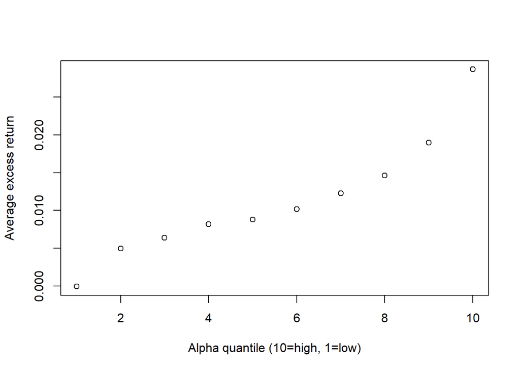

```r
df302q_alpha = df302q |>
  group_by(q_alpha) |>
  summarize(mean_rx = mean(rx_av))

plot(df302q_alpha$mean_rx, xlab = "Alpha quantile (10=high, 1=low)", ylab = "Average excess return")
```

.

## Q_beta returns

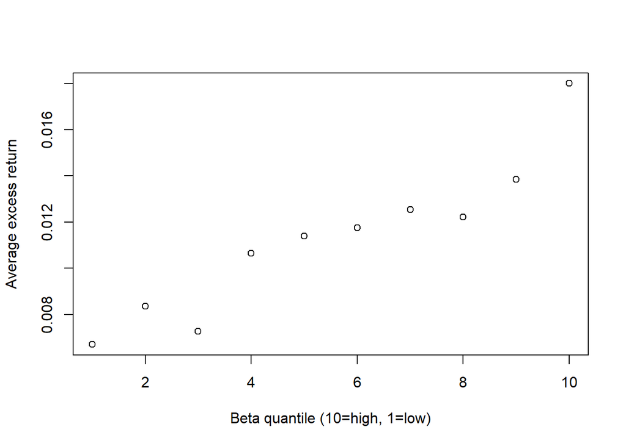

```r
df302q_beta = df302q |>
  group_by(q_beta) |>
  summarize(mean_rx = mean(rx_av))

plot(df302q_beta$mean_rx, xlab = "Beta quantile (10=high, 1=low)", ylab = "Average excess return")
```

.

## Q_sdx returns

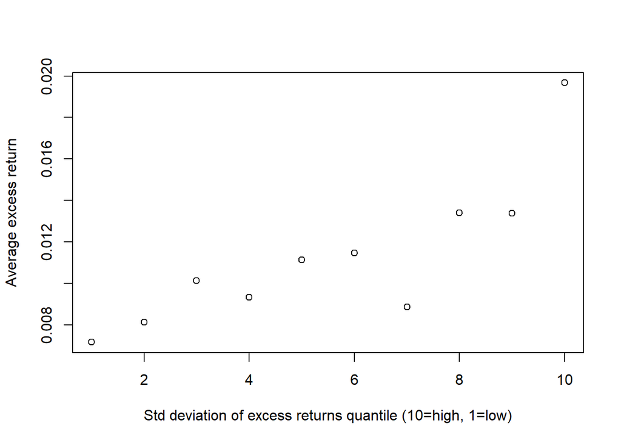

```r
df302q_sdx = df302q |>
  group_by(q_sdx) |>
  summarize(mean_rx = mean(rx_av))

plot(df302q_sdx$mean_rx, xlab = "Std deviation of excess returns quantile (10=high, 1=low)", ylab = "Average excess return")
```

.

## Q_sde returns

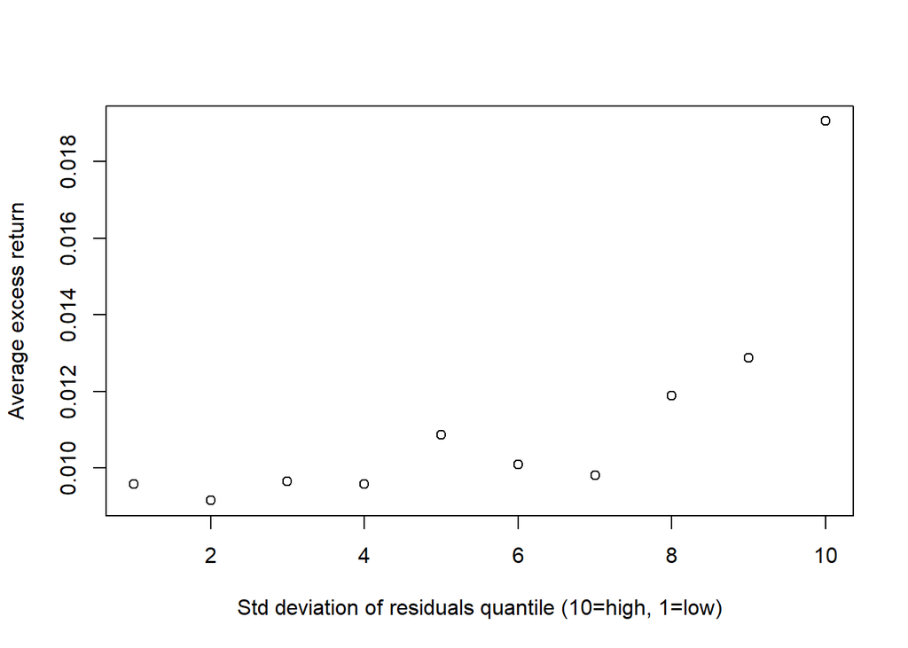

```r
df302q_sde = df302q |>
  group_by(q_sde) |>
  summarize(mean_rx = mean(rx_av))

plot(df302q_sde$mean_rx, xlab = "Std deviation of residuals quantile (10=high, 1=low)", ylab = "Average excess return")
```

**Note**

[Ang, Hodrick, Xing, and Zhang](https://doi.org/10.1111/j.1540-6261.2006.00836.x) (Journal of Finance, 2006) report that stocks with a high level of idiosyncratic (firm-specific) volatility of stocks (relative to a FF3 model over the past 60 days) can be a signal for under-performance in the future. Our analysis here is not comparable with their study, because we measure idiosyncratic risk over the whole period of 6 years.

.

# Quantile t-tests

## Prepare data

Let’s go back to the file `df302`, which is on a *ticker-month basis*, and attach the new variables we produced *at ticker level* in `df302q`. We then save this new file as `df303` into the project folder

```r
df303 = left_join(df302, df302q, join_by(ticker))

write.csv(df303, "df303.csv", fileEncoding = "UTF-8", row.names = FALSE)

#View(df303)
```

We clean and sort a bit for the next step

```r
df303 = df303 |>
  select(-ends_with("_hpr")) |>
  arrange(ticker, date)

View(df303)
```

.

## Q_beta t-test

Let’s run two-sample t-tests to compare the means of the highest and the lowest deciles.

```r
# Obtain the average excess return for beta quantile 10
Q10_beta = df303 |>
  filter(q_beta==10) |>
  distinct(ticker, .keep_all=TRUE) |> # keeps 1st full row of ticker
  select(rx_av)                       # keeps avrg return per ticker

View(Q10_beta)
```

**Note**

An alternative to using distinct() is group_by(ticker). This is particularly useful if you do not have a pre-computed rx_av in the dataframe. The following code is equivalent to the one above:

```
Q10_beta = df303 |>
  filter(q_beta==10) |>
  group_by(ticker) |>
  summarize(rx_av = mean(rx)) |>
  select(rx_av)
```

```r
# Obtain the average excess return for beta quantile 1
Q1_beta = df303 |>
  filter(q_beta==1) |>
  distinct(ticker, .keep_all=TRUE) |>
  select(rx_av)

# Test whether the average excess returns are different in Q10 vs. Q1
t.test(Q10_beta, Q1_beta, conf.level = 0.99)
```

[output not shown]

**Note**

In R, Welch’s t-test is the default of `t.test()`, which does not assume equal variances. The default confidence interval, without specifying `conf.level = 0.99`, is 0.95. The command would then simply be `t.test(Q10_beta, Q1_beta)`.

The difference is statistically significant. Stocks with the highest beta (top 10%) earn a higher excess return compared to stock with the lowest beta (bottom 10%), in our sample. Hence, we do find that taking on systematic risk is rewarded.

.

## Q_sdx t-test

```r
# Obtain the average excess return for standard deviation quantile 10
Q10_sdx = df303 |>
  filter(q_sdx==10) |>
  distinct(ticker, .keep_all=TRUE) |>
  select(rx_av)

# Obtain the average excess return for standard deviation quantile 1
Q1_sdx = df303 |>
  filter(q_sdx==1) |>
  distinct(ticker, .keep_all=TRUE) |>
  select(rx_av)

# Test whether the average excess returns are different in Q10 vs. Q1
t.test(Q10_sdx, Q1_sdx, conf.level = 0.99)
```

```
    Welch Two Sample t-test

data:  Q10_sdx and Q1_sdx
t = 4.9492, df = 52.47, p-value = 8.088e-06
alternative hypothesis: true difference in means is not equal to 0
99 percent confidence interval:
 0.005748294 0.019247027
sample estimates:
  mean of x   mean of y
0.019669212 0.007171552
```

Again, the difference is statistically significant. Stocks with the most total risk (top 10%) earn a higher excess return compared to stock with the least total risk (bottom 10%), in our sample.

.

## Q_sde t-test

```r
# Obtain the average excess return for residual standard deviation quantile 10
Q10_sde = df303 |>
  filter(q_sde==10) |>
  distinct(ticker, .keep_all=TRUE) |>
  select(rx_av)

# Obtain the average excess return for residual standard deviation quantile 1
Q1_sde = df303 |>
  filter(q_sde==1) |>
  distinct(ticker, .keep_all=TRUE) |>
  select(rx_av)

# Test whether the average excess returns are different in Q10 vs. Q1
t.test(Q10_sde, Q1_sde, conf.level = 0.99)
```

```
    Welch Two Sample t-test

data:  Q10_sde and Q1_sde
t = 3.7674, df = 54.403, p-value = 0.0004073
alternative hypothesis: true difference in means is not equal to 0
99 percent confidence interval:
 0.002759057 0.016171889
sample estimates:
  mean of x   mean of y
0.019053306 0.009587833
```

Once more, the difference is statistically significant. Stocks with the most non-systematic risk (top 10%) earn a higher excess return compared to stock with the least non-systematic risk (bottom 10%), in our sample. Apparently, taking on idiosyncratic risk is rewarded, which goes against predictions by the CAPM.

.

# Fama-French 3-Factor

Do high-beta portfolios and low-beta portfolios have different FF3 model results?

## Construct a high-beta portfolio

```r
# Obtain all Q10 beta stocks (high beta)
Q10_beta = df303 |>
  filter(q_beta==10) |>                # filter out the Q10 beta stocks
  group_by(date) |>                    # for each month..
  mutate(rx_av_Q10_beta = mean(rx)) |> # equal-weighted avg. excess return
  distinct(date, .keep_all = TRUE) |>  # keep 1st line (rm,HML,SMB identical per ticker-month)
  select(-ticker)

view(Q10_beta) # (see the last column)
```

.

## Construct a low-beta portfolio

```r
# Obtain all Q1 beta stocks (high beta)
Q1_beta = df303 |>
  filter(q_beta==1) |>                 # filter out the Q1 beta stocks
  group_by(date) |>                    # for each month..
  mutate(rx_av_Q1_beta = mean(rx)) |>  # equal-weighted avg. excess return
  distinct(date, .keep_all = TRUE) |>  # keep 1st line (rm,HML,SMB identical per ticker-month)
  select(-ticker)

view(Q1_beta) # (see the last column)
```

.

## FF3 for high-beta portfolio

```r
# Run a time-series regression (FF3)
lm_highbeta = lm(rx_av_Q10_beta ~ rm + SMB + HML, data = Q10_beta)

summary(lm_highbeta)
```

```
Call:
lm(formula = rx_av_Q10_beta ~ rm + SMB + HML, data = Q10_beta)

Residuals:
      Min        1Q    Median        3Q       Max
-0.073916 -0.021400 -0.001042  0.020100  0.134357

Coefficients:
            Estimate Std. Error t value Pr(>|t|)
(Intercept) 0.006254   0.004279   1.462    0.148
rm          1.691030   0.084105  20.106  < 2e-16 ***
SMB         0.947730   0.150828   6.284 2.70e-08 ***
HML         0.567555   0.097206   5.839 1.62e-07 ***
---
Signif. codes:  0 '***' 0.001 '**' 0.01 '*' 0.05 '.' 0.1 ' ' 1

Residual standard error: 0.03577 on 68 degrees of freedom
Multiple R-squared:  0.8964,    Adjusted R-squared:  0.8918
F-statistic: 196.1 on 3 and 68 DF,  p-value: < 2.2e-16
```

Positive loading on SMB, which means this portfolio is more exposed to small stocks compared to large stocks. Also, a positive loading on HML, which means this portfolio is exposed to high BM (value) as compared to low BM companies (growth). Finally, not surprisingly, a high market beta. Note also that the alpha is 0.6% but not statistically significant.

.

## FF3 for low-beta portfolio

```r
# Run a time-series regression (FF3)
lm_lowbeta = lm(rx_av_Q1_beta ~ rm + SMB + HML, data = Q1_beta)

summary(lm_lowbeta)
```

```
Call:
lm(formula = rx_av_Q1_beta ~ rm + SMB + HML, data = Q1_beta)

Residuals:
      Min        1Q    Median        3Q       Max
-0.052218 -0.014672 -0.001142  0.013704  0.061248

Coefficients:
             Estimate Std. Error t value Pr(>|t|)
(Intercept)  0.002912   0.002810   1.036  0.30377
rm           0.460096   0.055243   8.329 5.55e-12 ***
SMB         -0.320735   0.099070  -3.237  0.00187 **
HML          0.057548   0.063849   0.901  0.37060
---
Signif. codes:  0 '***' 0.001 '**' 0.01 '*' 0.05 '.' 0.1 ' ' 1

Residual standard error: 0.0235 on 68 degrees of freedom
Multiple R-squared:  0.5165,    Adjusted R-squared:  0.4951
F-statistic: 24.21 on 3 and 68 DF,  p-value: 9.039e-11
```

.